# MoBPS (1.14.00)

Torsten Pook

2026-04-29

This file descripts all updates of the software since 1.13.15

## New analysis functions

Added new functions get.stats.cohorts and get.stats.gen to compute genetic progress, inbreeding level and prediction accuracies for a set of cohort/generations and provide some basic visualizations.

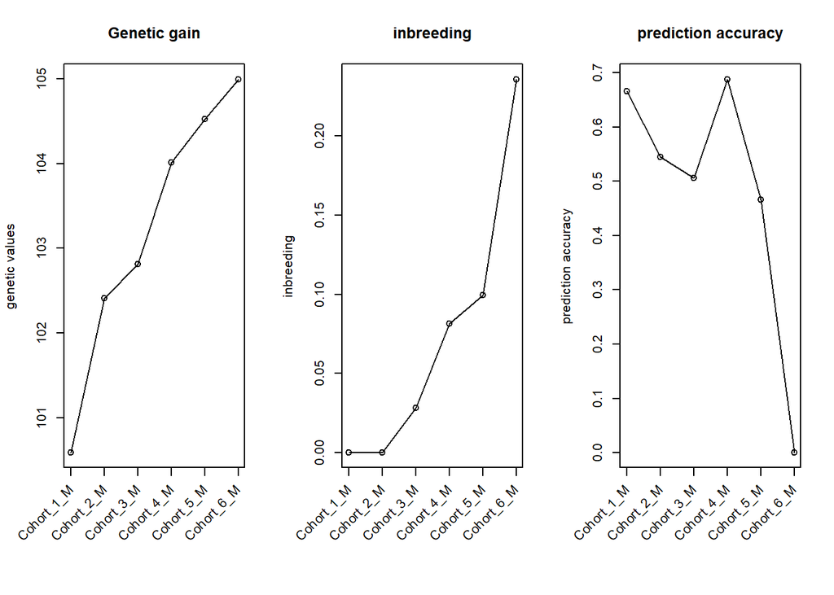

```r
library(MoBPS)
data(ex_pop)
get.stats.cohorts(ex_pop, cohort.filter = "_M")
```

## Renaming and Removal of Parameters

Parameter names in **MoBPS** have been revised to better align with standard breeding terminology.  
Rather than maintaining backward compatibility, outdated and deprecated parameters have been removed. This reduces long-term ambiguity and potential errors.

> If you need to reproduce older simulations, use a previous MoBPS version or update your scripts according to changed described below.

### Renamed Parameters in breeding.diploid

- `ogc` → `ocs`
  - Applies to all OCS-related parameters
- `threshold.selection` → `post.threshold.selection`
  - Clarifies that this operation occurs *after* selection and can result in less selected individuals than put in selection.size (e.g., to mimic individuals dying after selection is already done)
  - Standard threshold selection (before selection according to the index) remains unchanged is handled via:  
    `threshold.selection.value`, `threshold.selection.sign`, `threshold.selection.criteria`, `threshold.selection.index`

### Removed Modules in breeding.diploid

- **`reduce.group`**
  - Recommend to use `culling.*` parameters for all culling operations
- **`bit.storing`**
  - Removed outdated R implementation for bitwise storage
  - Does **not** affect the `RandomFieldsUtils` / `miraculix` implementation
- **`GWAS` module**
  - Removed due to inefficiency and outdated implementation
  - A more advanced implementation is planned (likely based on `statgenGWAS`) outside `breeding.diploid()`

### Renamed Functions

- `add.founder.kinship` → `add.founder.relationship`
  - Reflects that the function (even before renaming) expected a *relationship matrix*, not a kinship matrix
- `inbreeding.emp` → `get.inbreeding.emp`
- `inbreeding.exp` → `get.inbreeding.exp`
- `kinship.emp` → `get.kinship.emp`
- `kinship.exp` → `get.kinship.exp`

Aligns with the `get.*` naming convention used across MoBPS. As these are commonly used function, the “old” names can also be used to call the perform the same analysis.

### Removed “old” Parameters

Use the following replacements:

| Old Parameter | Replacement (that already existed) |
| --- | --- |
| `selection.m`, `selection.f` | `selection.criteria` |
| `shuffle.cor` | `trait.cor` |
| `shuffle.traits` | `trait.cor.include` |
| `multiple.bve.weights`, `multiple.bve.scale` | `selection.index.weights`, `selection.index.scale` |
| `offspring.bve` | `offpheno` |
| `new.phenotype.correlation` | `new.residual.correlation` |
| `computation.A` | `relationship.matrix` |
| `new.bv.child` | `phenotyping.child` |
| `new.bv.observation` | `phenotyping.gen`, `database`, or `cohorts` |
| `best1.from.group` | `selection.m.gen`, `database`, or `cohorts` |
| `input.phenotype` | `bve.input.phenotype` |
| `add.genotyped` | `share.genotyped` |

## User Manual

Revamp of the MoBPS Manual to be more Cook-book style with add additional code examples for individual parameter options in breeding.diploid() and creating.diploid().

## Underlying true breeding values

There is a difference between underlying true genetic values (what is referred to as “bv” in MoBPS) and underlying true breeding values (which is a term more commonly used (and mis-used) in practice). In particularly in crossbreeding / hybrid yield trials, it might be important to distinguish. Further features to help integrate underlying true breeding values in the analysis are planning in the future. Extended description was added to the User Manual.

```r
library(MoBPS)
set.seed(42)

# Generation of two pools of fully inbred material
population <- creating.diploid(dataset = "homorandom",
                               nsnp = 10000, chr.nr = 5, nindi = 10,
                               name.cohort = "Pool1", sex.quota = 0,
                               progress.bar = FALSE, verbose = FALSE)

population <- creating.diploid(population,
                               dataset = "homorandom", nindi = 10,
                               name.cohort = "Pool2", sex.quota = 1,
                               verbose = FALSE)

# Generation of the three different traits
population <- creating.trait(population, n.additive = c(10,1000,500),
                             n.dominant = c(0,0,500),
                             dominant.only.positive = TRUE,
                             verbose = FALSE)

population <- bv.standardization(population, mean.target = c(100,100,100),
                                 var.target = c(5,5,5))

population = calculate.empirical.bv(population, cohorts = "Pool1",
                                    reference.cohorts = "Pool2",
                       enter.population = TRUE, verbose = FALSE)

get.bv(population, cohorts = "Pool1")
```

```
##                 1        2         3         4        5         6        7
## Trait 1 101.09839 102.6894 101.73688  99.95245 99.85794  98.34607  98.7936
## Trait 2  98.79239 101.2504 100.74824  99.01772 97.78910 101.59018 102.6777
## Trait 3 102.19374 101.4660  99.29943 101.19638 97.47601  98.66870 100.5886
##                 8         9        10
## Trait 1 104.38657 100.71555  99.45971
## Trait 2 101.34899 103.94344 100.56632
## Trait 3  97.96029  96.69194  95.94547
```

```r
get.empirical.bv(population, cohorts = "Pool1")
```

```
##                 1        2         3         4         5         6         7
## Trait 1 100.16103 100.8619 100.37682  99.52504  99.66855  98.81556  99.03851
## Trait 2  98.99791 100.0215  99.92411  99.20068  98.45626 100.55794 100.86741
## Trait 3 110.08522 109.5915 108.12750 109.09085 108.15652 107.81505 109.21536
##                8        9        10
## Trait 1 101.7730 100.0118  99.12148
## Trait 2 100.3673 101.6135  99.74004
## Trait 3 107.6406 107.4412 106.54305
```

## MSV

MoBPS now includes a direct link to the msv-software to estimate MSV term (calculate.msv) and export (get.msv). MSV can also be used as an additional selection criterion by setting selection.criteria = “msv”

```r
set.seed(1)
setwd("C:/Users/pook001/OneDrive - Wageningen University & Research/")
library(MoBPS)

## Generation of the baseline population

population = creating.diploid(nsnp = 25000, nindi = c(10,10),
                              chr.nr = 10, chromosome.length = 2.5,
                              n.additive = c(100,100) ,
                              share.genotyped = 1, verbose = FALSE,
                              progress.bar = FALSE)

population = breeding.diploid(population, heritability = 0.3)
```

```
## Start deriving enviromental variance (according to given heritability).
## Estimated residual variances: 76.489 109.3322
```

```r
for(index in 1:10){
  population = breeding.diploid(population, phenotyping.gen = get.ngen(population),
                                verbose = FALSE)
  population = breeding.diploid(population, selection.size = c(2, 2), breeding.size = c(10, 10),
                                selection.criteria = "pheno",
                                share.genotyped = 1,
                                verbose = FALSE)
}


population = bv.standardization(population, mean.target = 100, var.target = 1,
                                gen = get.ngen(population),
                                adapt.pheno = TRUE,
                                verbose = FALSE)

current_gen = get.ngen(population)

population = breeding.diploid(population, heritability = 0.3, sigma.e.gen = current_gen, verbose = FALSE)
population = breeding.diploid(population, phenotyping.gen = current_gen,
                              verbose = FALSE)

population = breeding.diploid(population, bve = TRUE, bve.gen = current_gen, estimate.u = TRUE, verbose = FALSE)

### MSV software currently only available to B4F - partners
population = calculate.msv(population, gen = 11,
                           msv.path = "C:/Users/pook001/OneDrive - Wageningen University & Research/msv")
```

```
## Writing: MSV_files/paternal_plink.bed
```

```
## Writing: MSV_files/paternal_plink.bim
```

```
## Writing: MSV_files/paternal_plink.fam
```

```
## Writing: MSV_files/maternal_plink.bed
```

```
## Writing: MSV_files/maternal_plink.bim
```

```
## Writing: MSV_files/maternal_plink.fam
```

```r
get.msv(population, gen = 11)
```

```
##              201      202      203     204      205      206      207      208
## Trait 1 101.4048 101.3813 100.9966 102.036 100.4389 100.6031 101.5106 101.7133
## Trait 2 101.4048 101.3813 100.9966 102.036 100.4389 100.6031 101.5106 101.7133
##              209      210      211      212      213      214      215      216
## Trait 1 100.2519 101.6208 102.0508 101.3183 101.4353 100.4616 101.1616 100.5341
## Trait 2 100.2519 101.6208 102.0508 101.3183 101.4353 100.4616 101.1616 100.5341
##              217      218      219      220
## Trait 1 101.6814 101.1016 100.8646 101.3481
## Trait 2 101.6814 101.1016 100.8646 101.3481
```

## Results of previous breeding value estimation

Whenever a breeding value estimation is performed, the EBVs of all included individuals are overwritten, unless you specify for which individuals to enter EBVs through bve.insert.gen/database/cohort . A new feature was added to store all EBVs, to retrospectively analyze them

```r
library(MoBPS)

## Generation of the baseline population

population = creating.diploid(nsnp = 25000, nindi = 100,
                              chr.nr = 10, n.additive = 100,
                              verbose = FALSE, progress.bar = FALSE)

population = breeding.diploid(population, heritability = 0.3, verbose = FALSE)

for(index in 1:10){
  population = breeding.diploid(population, phenotyping.gen = get.ngen(population),
                                verbose = FALSE)
  population = breeding.diploid(population, selection.size = c(10,10), breeding.size = 100,
                                selection.criteria = "pheno",
                                verbose = FALSE)
}

population = breeding.diploid(population, bve = TRUE, bve.gen = 9:10, verbose = FALSE)

# Option 1: Only enter EBVs for new individuals
pop1 = breeding.diploid(population, bve = TRUE, bve.gen = 10:11,
                              bve.insert.gen = 11, verbose = FALSE)

# Option 2: Only enter EBVs for new individuals
pop2 = bve.store(population, gen = 10)
pop2 = breeding.diploid(pop2, bve = TRUE, bve.gen = 10:11, verbose = FALSE)

get.bve.stored(pop2, gen = 10)
```

```
##              901      902      903      904      905      906      907      908
## Trait 1 125.2368 125.4154 124.5859 127.0028 124.3093 127.6349 128.8977 126.5679
##              909     910     911      912      913     914      915      916
## Trait 1 122.3241 126.701 121.935 124.5322 128.1401 127.622 123.3603 126.4433
##              917      918      919      920     921      922      923      924
## Trait 1 125.1455 125.1631 128.9383 126.3425 121.968 128.6292 125.6326 125.8851
##              925      926      927      928      929      930      931      932
## Trait 1 125.7828 128.3516 126.8601 127.7264 123.9362 125.2237 125.4635 126.6951
##              933      934      935      936      937      938     939      940
## Trait 1 127.1023 124.1827 123.5351 124.6647 127.2701 123.8915 127.357 123.4198
##              941      942      943      944      945      946      947      948
## Trait 1 124.5017 128.8279 126.5906 122.9575 124.3384 124.3162 128.0384 125.3896
##              949      950      951      952      953     954      955      956
## Trait 1 126.6674 127.4528 123.7896 125.2153 123.9081 126.782 124.2744 125.4374
##              957      958      959      960      961      962      963      964
## Trait 1 127.4565 126.5092 122.6539 124.8182 127.5256 125.8367 125.0494 125.0116
##              965      966      967      968      969      970     971      972
## Trait 1 123.7591 126.7374 128.7326 126.5645 125.1088 124.6389 127.967 122.4666
##             973     974      975      976      977      978      979      980
## Trait 1 128.564 124.742 124.7176 126.1901 123.4609 123.6366 122.0409 123.5615
##              981      982      983      984     985      986      987      988
## Trait 1 127.3732 127.8533 127.1078 127.8762 123.177 129.1793 127.7667 124.2696
##              989      990      991      992      993     994      995      996
## Trait 1 126.4875 123.9212 125.9225 126.3052 127.9022 123.735 126.5754 127.4896
##              997      998      999     1000
## Trait 1 121.8766 124.7459 125.1142 124.5068
```

```r
analyze.bv(pop2, gen = 10, add = "stored")[[1]]
```

```
##               Trait 1
## BV / BVE    0.5477157
## BV / Pheno  0.4366329
## BVE / Pheno 0.7651967
## BV / ADD    0.5217127
## BVE / ADD   0.9686155
## Pheno / ADD 0.7806394
```

```r
# First value: Accuracy in current evaluation
# Forth value: Accuracy in the previous evaluation
```

## analyze.bv

Analyze.bv now also supports analysis of the MSV term (“msv”), previous breeding values (“stored”), underlying true empirical breeding values (“empirical”), and offspring phenotypes (“offpheno”) through the add parameter (example see above)

## Misc

Various smaller bug-fixes and improved prints to give more feedback on potential issues in code.